# Creative Gaming: Propensity Modeling for Ad Targeting

Deepa Das

# Preliminaries

### Determine notebook defaults:

### Load packages:

### Read in the data:

```r
# use load("../data/filename.Rdata") for .Rdata files
load("../data/creative_gaming.Rdata")
```

# Assignment answers

## Part1 :What is the probability of organically converting to Zalon?

##For each feature, show basic summary statistics.

```r
## 1. Probability of organically converting to Zalon
# ---------------------------------------------------
# The variable is "converted" in the cg_organic dataframe
prob_conversion <- mean(cg_organic$converted)
prob_conversion
```

```
[1] 0.05753333
```

```r
# 2. Basic summary statistics for each feature
# ---------------------------------------------------
# Using skim_without_charts() to display summary statistics
skim_without_charts(cg_organic)
```

Data summary

| Name | cg_organic |
| --- | --- |
| Number of rows | 30000 |
| Number of columns | 20 |
| _______________________ |  |
| Column type frequency: |  |
| factor | 6 |
| numeric | 14 |
| ________________________ |  |
| Group variables | None |

**Variable type: factor**

| skim_variable | n_missing | complete_rate | ordered | n_unique | top_counts |
| --- | --- | --- | --- | --- | --- |
| AcquiredSpaceship | 0 | 1 | FALSE | 2 | 0: 21695, 1: 8305 |
| AcquiredIonWeapon | 0 | 1 | FALSE | 2 | 0: 29439, 1: 561 |
| PurchasedCoinPackSmall | 0 | 1 | FALSE | 2 | 0: 19857, 1: 10143 |
| PurchasedCoinPackLarge | 0 | 1 | FALSE | 2 | 0: 22061, 1: 7939 |
| UserNoConsole | 0 | 1 | FALSE | 2 | 0: 24546, 1: 5454 |
| UserHasOldOS | 0 | 1 | FALSE | 2 | 0: 27411, 1: 2589 |

**Variable type: numeric**

| skim_variable | n_missing | complete_rate | mean | sd | p0 | p25 | p50 | p75 | p100 |
| --- | --- | --- | --- | --- | --- | --- | --- | --- | --- |
| converted | 0 | 1 | 0.06 | 0.23 | 0 | 0 | 0 | 0 | 1 |
| GameLevel | 0 | 1 | 6.25 | 2.77 | 1 | 4 | 7 | 9 | 10 |
| NumGameDays | 0 | 1 | 12.24 | 7.10 | 1 | 6 | 13 | 18 | 28 |
| NumGameDays4Plus | 0 | 1 | 1.26 | 3.19 | 0 | 0 | 0 | 0 | 24 |
| NumInGameMessagesSent | 0 | 1 | 73.78 | 107.44 | 0 | 0 | 26 | 112 | 1227 |
| NumSpaceHeroBadges | 0 | 1 | 0.44 | 1.52 | 0 | 0 | 0 | 0 | 12 |
| NumFriendRequestIgnored | 0 | 1 | 29.59 | 33.99 | 0 | 0 | 16 | 53 | 121 |
| NumFriends | 0 | 1 | 47.73 | 94.33 | 0 | 0 | 5 | 43 | 486 |
| TimesLostSpaceship | 0 | 1 | 4.44 | 11.55 | 0 | 0 | 0 | 4 | 298 |
| TimesKilled | 0 | 1 | 0.29 | 3.42 | 0 | 0 | 0 | 0 | 178 |
| TimesCaptain | 0 | 1 | 1.58 | 8.77 | 0 | 0 | 0 | 0 | 429 |
| TimesNavigator | 0 | 1 | 1.40 | 7.95 | 0 | 0 | 0 | 0 | 545 |
| NumAdsClicked | 0 | 1 | 9.49 | 7.40 | 0 | 4 | 8 | 12 | 38 |
| DaysUser | 0 | 1 | 2626.37 | 661.43 | 244 | 2162 | 2557 | 3105 | 4139 |

```r
prob_conversion
```

```
[1] 0.05753333
```

```r
#The probability of organically converting is 5.75% . Summary statistics for each feature is generated below.
```

## Part 2: Predictive Model

##1. Create a training and test sample based on the “cg_organic” dataframe. ## What is the training/test split percentage?

```r
## Converting into factors
cg_organic <- cg_organic %>%
  mutate(AcquiredSpaceship=factor(AcquiredSpaceship),
         AcquiredIonWeapon=factor(AcquiredIonWeapon),
                 PurchasedCoinPackSmall=factor(PurchasedCoinPackSmall),
         PurchasedCoinPackLarge=factor(PurchasedCoinPackLarge),
                 UserNoConsole=factor(UserNoConsole),
         UserHasOldOS=factor(UserHasOldOS),
         converted=factor(converted))

## Creating a training and test sample based on the “cg_organic” dataframe.
cg_organic_train <- cg_organic[sample_train_org, ]

# Creating the test sample
cg_organic_test <- cg_organic[-sample_train_org, ]

# Check how many rows are in each sample
nrow(cg_organic_train)
```

```
[1] 21000
```

```r
nrow(cg_organic_test)
```

```
[1] 9000
```

```r
# Calculate the training/testing split percentage
cg_organic_train_percent <- nrow(cg_organic_train) / nrow(cg_organic) * 100
cg_organic_test_percent <- nrow(cg_organic_test) / nrow(cg_organic) * 100

cg_organic_train_percent
```

```
[1] 70
```

```r
cg_organic_test_percent
```

```
[1] 30
```

```r
# Created a training and test data set. The split percentage is 70% to 30%
```

##Train a logistic regression model using all features. ## a)What are the 5 most important features? ## b) For each of these 5 feature, make a partial dependence plot and summarize your findings. ## c) Plot the gains curve in the test sample and report the AUC of the model.

```r
formula <- as.formula(converted ~ GameLevel + NumGameDays + NumGameDays4Plus +
                        NumInGameMessagesSent + NumSpaceHeroBadges + NumFriendRequestIgnored +NumFriends + AcquiredSpaceship + AcquiredIonWeapon + TimesLostSpaceship +TimesKilled + TimesCaptain + TimesNavigator + PurchasedCoinPackSmall +PurchasedCoinPackLarge + NumAdsClicked +DaysUser + UserNoConsole + UserHasOldOS)

model_log.0 <- glm(formula,
               family = "binomial", cg_organic_train)
summary(model_log.0)
```

```
Call:
glm(formula = formula, family = "binomial", data = cg_organic_train)

Coefficients:
                          Estimate Std. Error z value Pr(>|z|)
(Intercept)             -4.570e+00  1.835e-01 -24.903  < 2e-16 ***
GameLevel                1.036e-01  1.404e-02   7.380 1.59e-13 ***
NumGameDays              3.309e-02  5.463e-03   6.058 1.38e-09 ***
NumGameDays4Plus         4.087e-02  8.793e-03   4.648 3.36e-06 ***
NumInGameMessagesSent    1.470e-03  3.712e-04   3.961 7.46e-05 ***
NumSpaceHeroBadges       4.178e-01  1.307e-02  31.961  < 2e-16 ***
NumFriendRequestIgnored -1.186e-02  1.291e-03  -9.181  < 2e-16 ***
NumFriends               1.296e-03  3.085e-04   4.201 2.66e-05 ***
AcquiredSpaceship1       5.382e-01  7.189e-02   7.486 7.09e-14 ***
AcquiredIonWeapon1       4.780e-01  2.031e-01   2.353 0.018625 *
TimesLostSpaceship      -3.980e-02  5.218e-03  -7.627 2.40e-14 ***
TimesKilled             -1.583e-02  1.684e-02  -0.940 0.347067
TimesCaptain            -3.384e-03  3.877e-03  -0.873 0.382708
TimesNavigator          -2.365e-02  6.554e-03  -3.608 0.000308 ***
PurchasedCoinPackSmall1 -9.242e-02  7.024e-02  -1.316 0.188241
PurchasedCoinPackLarge1  2.389e-01  7.335e-02   3.257 0.001124 **
NumAdsClicked            2.696e-02  3.753e-03   7.183 6.83e-13 ***
DaysUser                -6.865e-06  5.098e-05  -0.135 0.892878
UserNoConsole1          -1.852e-01  9.147e-02  -2.025 0.042897 *
UserHasOldOS1           -1.665e-01  1.242e-01  -1.341 0.179980
---
Signif. codes:  0 '***' 0.001 '**' 0.01 '*' 0.05 '.' 0.1 ' ' 1

(Dispersion parameter for binomial family taken to be 1)

    Null deviance: 9120.7  on 20999  degrees of freedom
Residual deviance: 7438.1  on 20980  degrees of freedom
AIC: 7478.1

Number of Fisher Scoring iterations: 6
```

```r
confint(model_log.0)
```

```
                                2.5 %        97.5 %
(Intercept)             -4.9317141411 -4.212309e+00
GameLevel                0.0762478058  1.312872e-01
NumGameDays              0.0224116857  4.382852e-02
NumGameDays4Plus         0.0234548028  5.793855e-02
NumInGameMessagesSent    0.0007345064  2.190020e-03
NumSpaceHeroBadges       0.3923592953  4.436159e-01
NumFriendRequestIgnored -0.0144099044 -9.347103e-03
NumFriends               0.0006830984  1.893003e-03
AcquiredSpaceship1       0.3968049248  6.786936e-01
AcquiredIonWeapon1       0.0606286789  8.592280e-01
TimesLostSpaceship      -0.0504218903 -2.997586e-02
TimesKilled             -0.0558162729  1.048621e-02
TimesCaptain            -0.0117743009  3.375579e-03
TimesNavigator          -0.0373947710 -1.172835e-02
PurchasedCoinPackSmall1 -0.2308785148  4.453677e-02
PurchasedCoinPackLarge1  0.0941988130  3.818327e-01
NumAdsClicked            0.0195535681  3.426894e-02
DaysUser                -0.0001069299  9.293843e-05
UserNoConsole1          -0.3673090223 -8.553355e-03
UserHasOldOS1           -0.4164504295  7.079375e-02
```

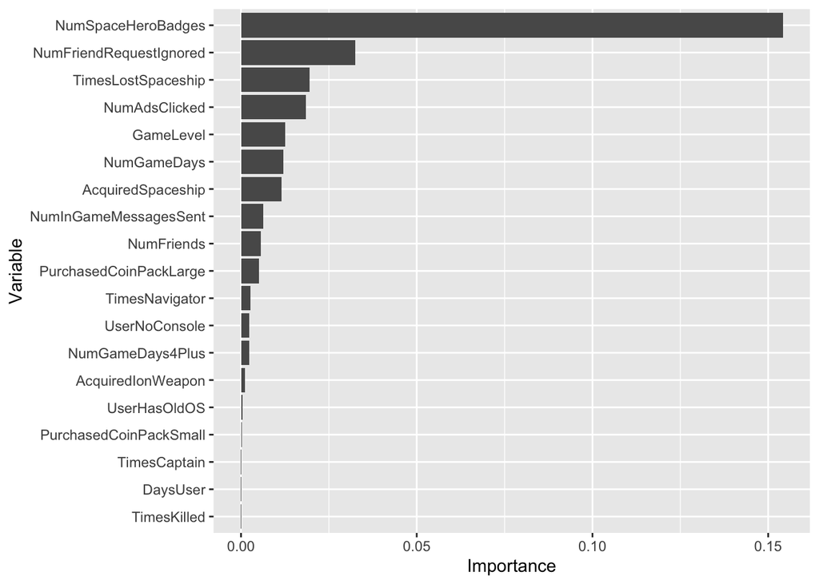

```r
## Variable Importance plots
varimpplot(model_log.0, target = "converted", data = cg_organic_train)
```

```r
# The top 5 important variables are NumSpaceHeroBadges, NumFriendRequestIgnored,
#TimesLostSpaceship, GameLevel,NumAdsClicked.
```

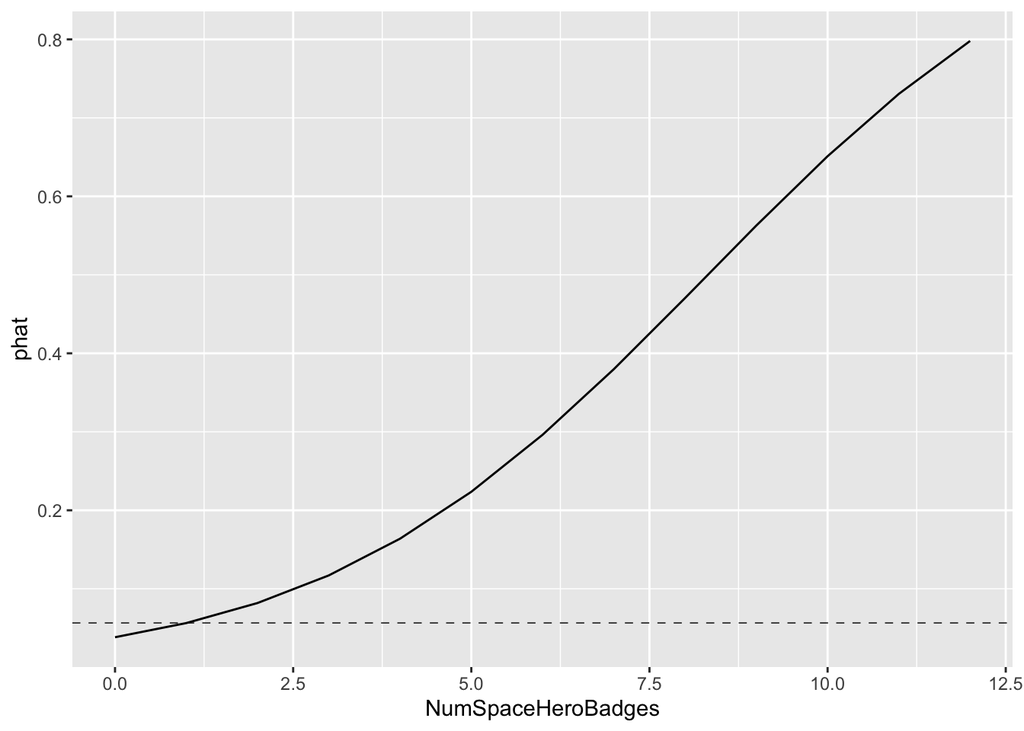

```r
## Partial dependence plots for the 5 most important variables

converted.overall <- mean(cg_organic_train$converted==1)
pardepplot(model_log.0, pred.var="NumSpaceHeroBadges", data=cg_organic_train, hline=converted.overall)
```

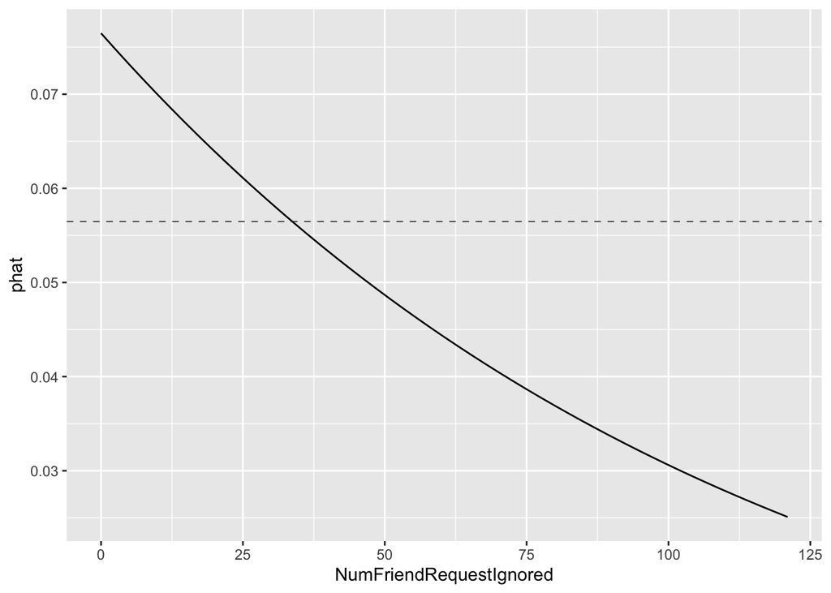

```r
## The Partial Dependence Plot for NumSpaceHeroBadges shows a strong positive relationship with conversion probability. As players earn more Space Hero Badges, their predicted likelihood of purchasing the Zalon campaign increases significantly. Players with few or no badges are unlikely to convert, while players with many badges (10 or more) are very likely to convert. This suggests that in-game achievement and engagement are highly predictive of purchase behavior.

pardepplot(model_log.0, pred.var="NumFriendRequestIgnored", data=cg_organic_train, hline=converted.overall)
```

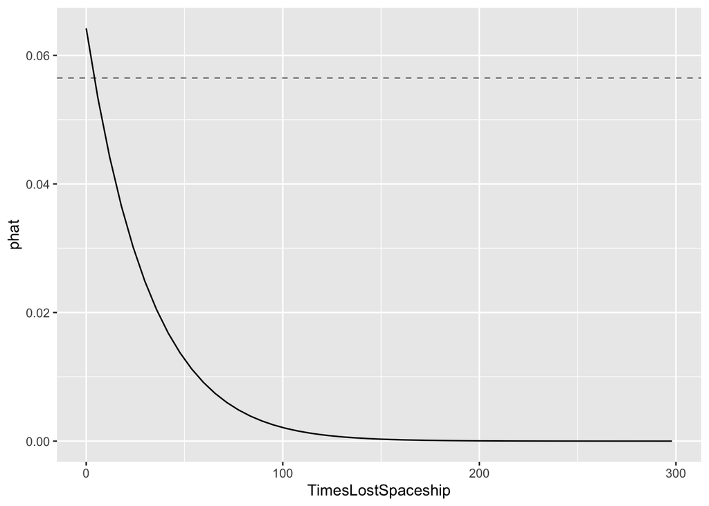

```r
## The Partial Dependence Plot for NumFriendRequestIgnored shows a strong negative relationship with conversion probability. As players ignore more friend requests,
## their predicted likelihood of purchasing the Zalon campaign decreases steadily.
## This suggests that more socially engaged players (who interact positively with others) are more inclined to purchase upgrades like Zalon.


pardepplot(model_log.0, pred.var="TimesLostSpaceship", data=cg_organic_train, hline=converted.overall)
```

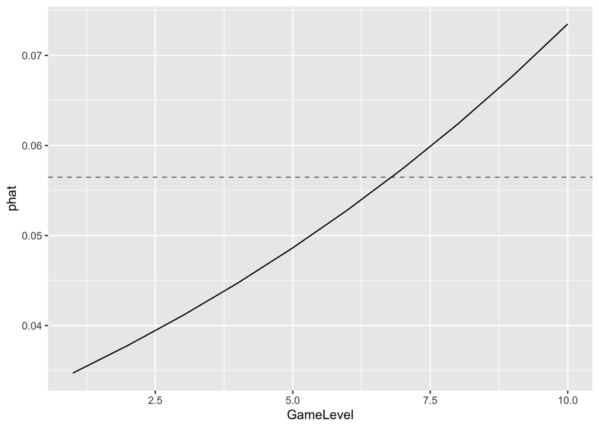

```r
## The Partial Dependence Plot for TimesLostSpaceship shows a sharp negative relationship with conversion probability. Players who have lost few spaceships are significantly more likely to purchase Zalon, while players who have lost many
## spaceships have an extremely low probability of converting. This suggests that struggling or less successful players may be less invested in upgrading their
## gameplay experience.

pardepplot(model_log.0, pred.var="GameLevel", data=cg_organic_train, hline=converted.overall)
```

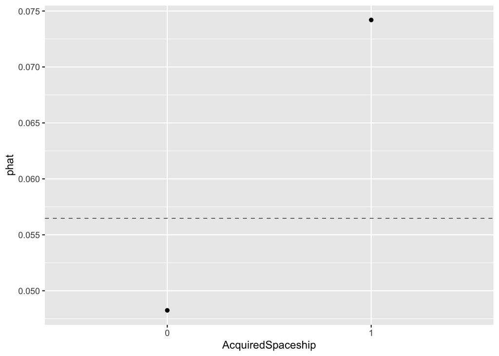

```r
##The Partial Dependence Plot for GameLevel shows a positive relationship with conversion probability. Players at higher levels are more likely to purchase the
##Zalon campaign. This suggests that deeper investment and progression within the
## game increase players' willingness to spend on upgrades or expansions.



pardepplot(model_log.0, pred.var="AcquiredSpaceship", data=cg_organic_train, hline=converted.overall)
```

```r
## The Partial Dependence Plot for AcquiredSpaceship shows a strong relationship
## with conversion probability. Players who had previously acquired a spaceship are significantly more likely to purchase the Zalon campaign than those who had not.
## This indicates that prior willingness to invest in in-game upgrades is a strong predictor of future purchase behavior.
```

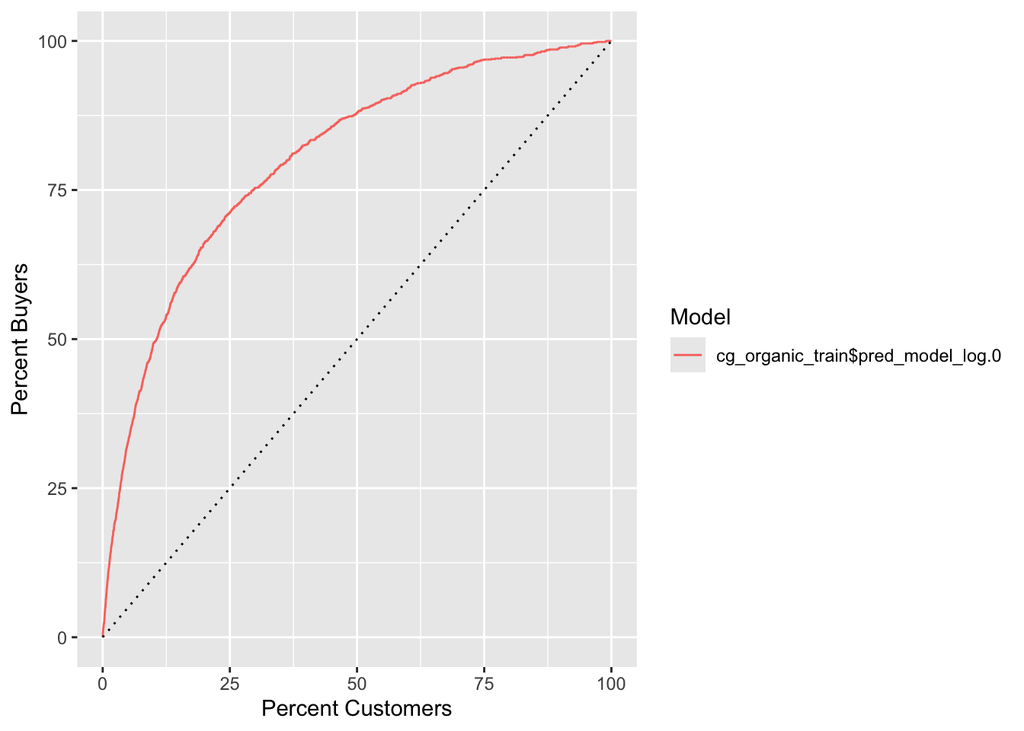

```
# A tibble: 1 × 2
  model                               auc
  <chr>                             <dbl>
1 cg_organic_train$pred_model_log.0  0.82
```

```r
### Carrying out gains plot analysis
cg_organic_test<-cg_organic_test %>%
  mutate(pred_model_log.0 = predict(model_log.0,
                              newdata = cg_organic_test,
                              type = "response"))

cg_organic_train<-cg_organic_train %>%
  mutate(pred_model_log.0 = predict(model_log.0,
                              newdata = cg_organic_train,
                              type = "response"))
#Creating gainsplot for training data
gainsplot(cg_organic_train$pred_model_log.0, label.var = cg_organic_train$converted)
```

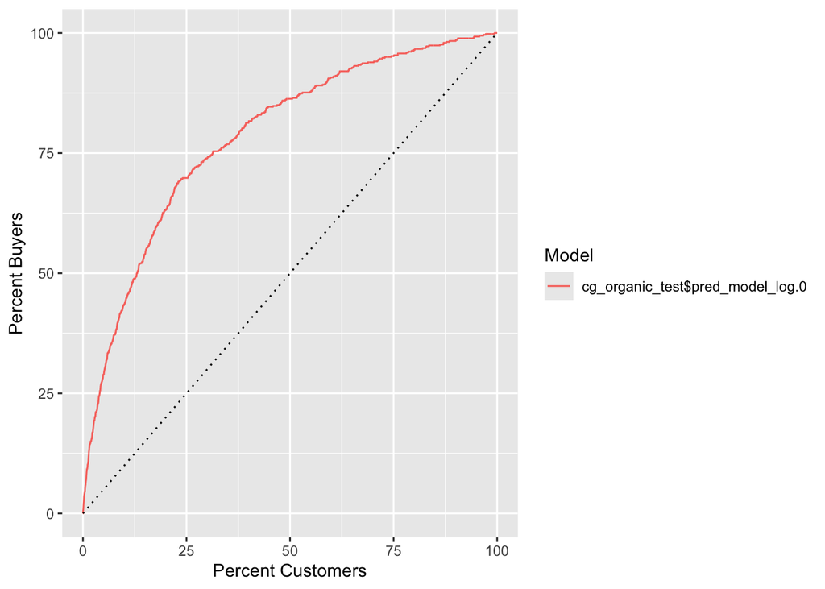

```
# A tibble: 1 × 2
  model                              auc
  <chr>                            <dbl>
1 cg_organic_test$pred_model_log.0 0.803
```

```r
#Creating gainsplot for test data
gainsplot(cg_organic_test$pred_model_log.0, label.var = cg_organic_test$converted)
```

```r
## The AUC for train data set is 0.82
## The AUC for test data set is 0.803
```